# L10-Cartograms

This document demonstrates how to visualize and explore spatial data in Ireland using cartograms — thematic maps that distort geometry to reflect a specific data variable. The dataset used includes median household income across Irish counties, which is transformed into a series of cartographic representations using R.

Three types of cartograms are created to highlight different aspects of spatial distortion:

- Non-contiguous cartogram: Counties are resized based on income but do not maintain adjacency.
- Contiguous cartogram: Counties are distorted in shape and size while preserving connections between them.
- Dorling cartogram: Counties are represented as non-overlapping circles sized proportionally to income.

Each visualization is produced using the tmap package in plot mode, offering a clear and interpretable visual comparison of regional income distribution.

```r
# Function to quietly install and load packages
quiet_library <- function(pkg) {
  suppressMessages(suppressWarnings({
    if (!requireNamespace(pkg, quietly = TRUE)) {
      install.packages(pkg, quiet = TRUE) # Install without messages
    }
    library(pkg, character.only = TRUE) # Load silently
  }))
}

quiet_library("sf")               # For handling spatial data
quiet_library("geojsonio")        # For reading geo json data
quiet_library("cartogram")        # For creating cartograms
quiet_library("rnaturalearth")    # Provides world map data
quiet_library("rnaturalearthdata")
quiet_library("tmap")             # Mapping package - like ggplot but for maps
quiet_library("rmapshaper")        # Used to simplify shapes for contiguous cartogram
quiet_library("tidyverse")

mydata <- file.path("C:","Datasets")
```

```r
# setup the data for Ireland
ireland <- rnaturalearth::ne_countries(scale = "medium", country = "Ireland", returnclass = "sf")

# Setup dataframe with longitude and latitude of major cities
cities <- data.frame(
  name = c("Dublin", "Cork", "Limerick", "Galway"),
  lon = c(-6.2603, -8.472, -8.6305, -9.0568),
  lat = c(53.3498, 51.8985, 52.6680, 53.2707)
)

# Using the shape data downloaded from
# Replace this with your actual file path
json_file <- file.path(mydata, "gadm41_IRL_1.json")

# Read the GeoJSON file into an sf object
countyshapes <- sf::st_read(json_file)
# Replace NAME_1 with "Cork" where VARNAME_1 is "Corcaigh"
# For some reason some Cork data is NA for NAME_1 but has the Irish equivalen
countyshapes$NAME_1[countyshapes$VARNAME_1 == "Corcaigh"] <- "Cork"

# Read in a file from CSO data of median income per electoral region
incomeloc <-file.path(mydata,"MedianIncomeIreland.csv" )
countyincome <-read.csv(incomeloc)

# Using a regular expression, extract county name after "Co." or Ending with Dublin, Cork City or Tipperary and add to the same dataset as column county
countyincome$county <- str_extract(countyincome$Electoral.Division,
                                      "(?<=Co\\. )\\w+|Dublin$|Cork City$|Tipperary$")

# Regular Expression explanation:
# (?<=Co\. )\w+ - This is a lookbehind (?<=...), which ensures that the match only occurs if it is preceded by "Co. " (e.g., "Co. Mayo").
# \w+ matches one or more word characters (letters, numbers, or underscores), so it captures county names like "Mayo", "Galway", etc., after "Co. ".
# The | means OR.
# Dublin$ matches "Dublin" only if it appears at the end of the string ($ means end of the string).
# Cork City$ Matches "Cork City" only if it appears at the end of the string.
#  Tipperary$ Matches "Tipperary" only if it appears at the end of the string.

# Replace Cork City by Cork
countyincome <- countyincome %>%
  mutate(county = case_when(
    county == "Cork City" ~ "Cork",
    TRUE ~ county
  ))
# Rename column "VALUE" to "avg_income"
countyincome <- countyincome %>%
  rename(mdn_income = VALUE)
countyincome <- na.omit(countyincome)

# Summarize avg_income by county_name, omitting nas
summary_df <- na.omit(countyincome) %>%
  group_by(county) %>%
  summarize(mdn_income = median(mdn_income, na.rm = TRUE))


# Merge income data with spatial county boundaries
counties_income <- countyshapes %>%
  inner_join(summary_df, by = c("NAME_1" = "county")) %>% # Ensure column names match
  st_as_sf()  # Ensure it remains a spatial object with geometry


# Define a new projection (Irish Traverse Mercator)
crs_itransm <- 2157

# Reproject all spatial data
ireland_proj <- sf::st_transform(ireland, crs_itransm)
counties_proj <- sf::st_transform(countyshapes, crs_itransm)
counties_income_proj <- sf::st_transform(counties_income, crs_itransm)

# Convert city coordinates to projected CRS
cities_proj <- cities %>%
  st_as_sf(coords = c("lon", "lat"), crs = 2157) %>%
  st_transform(crs_itransm) %>%
  st_coordinates() %>%
  as.data.frame() %>%
  mutate(name = cities$name)
```

# Non-contiguous Cartogram

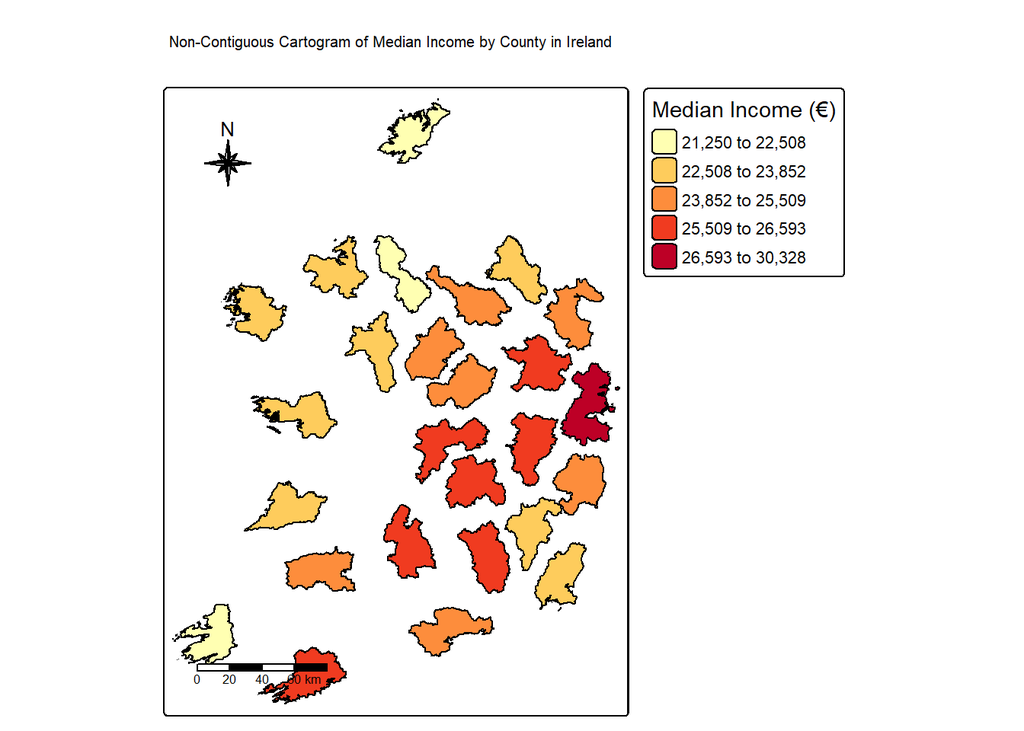

```r
# Ensure projected CRS
counties_income_proj <- sf::st_transform(counties_income, 2157)  # EPSG:2157 for Ireland

# Create a non-contiguous cartogram
counties_ncont <- cartogram::cartogram_ncont(counties_income_proj, "mdn_income")

# Plot using tmap v4
tmap::tmap_mode("plot")

tmap::tm_shape(counties_ncont) +
  tm_polygons(
    fill = "mdn_income",
    fill.scale = tm_scale_intervals(values = "brewer.yl_or_rd", style = "jenks"),
    fill.legend = tm_legend(title = "Median Income (€)"),
    col = "black"
  ) +
  tm_scalebar(position = c("left", "bottom")) +
  tm_compass(type = "8star", size = 2, position = c("left", "top")) +
  tm_title("Non-Contiguous Cartogram of Median Income by County in Ireland")
```

# Contiguous Cartogram

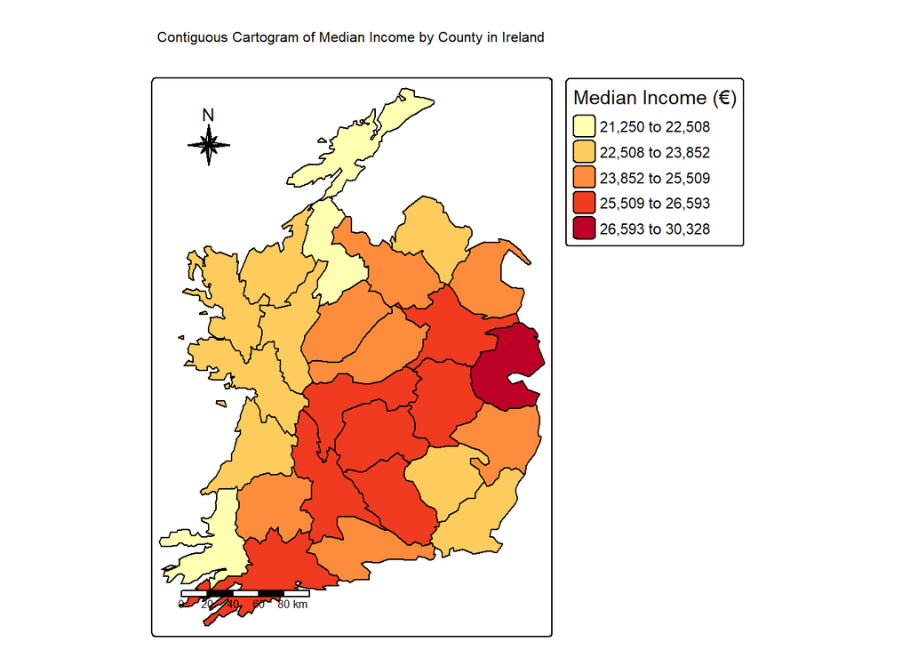

```r
# Simplify geometries before creating the cartogram
county_income_simplified <- rmapshaper::ms_simplify(counties_income_proj, keep = 0.05)  # keep 5% of points


# Then generate the cartogram
counties_cont <- cartogram::cartogram_cont(county_income_simplified, weight = "mdn_income", itermax = 5)


# Plot using tmap v4
tmap::tmap_mode("plot")
# Set autoscale globally
tmap::tmap_options(component.autoscale = TRUE)

tmap::tm_shape(counties_cont) +
  tm_polygons(
    fill = "mdn_income",
    fill.scale = tm_scale_intervals(values = "brewer.yl_or_rd", style = "jenks"),
    fill.legend = tm_legend(title = "Median Income (€)"),
    col = "black"
  ) +
  tm_scalebar(position = c("left", "bottom")) +
  tm_compass(type = "8star", size = 2, position = c("left", "top")) +
  tm_title("Contiguous Cartogram of Median Income by County in Ireland")
```

# Dorling Cartogram

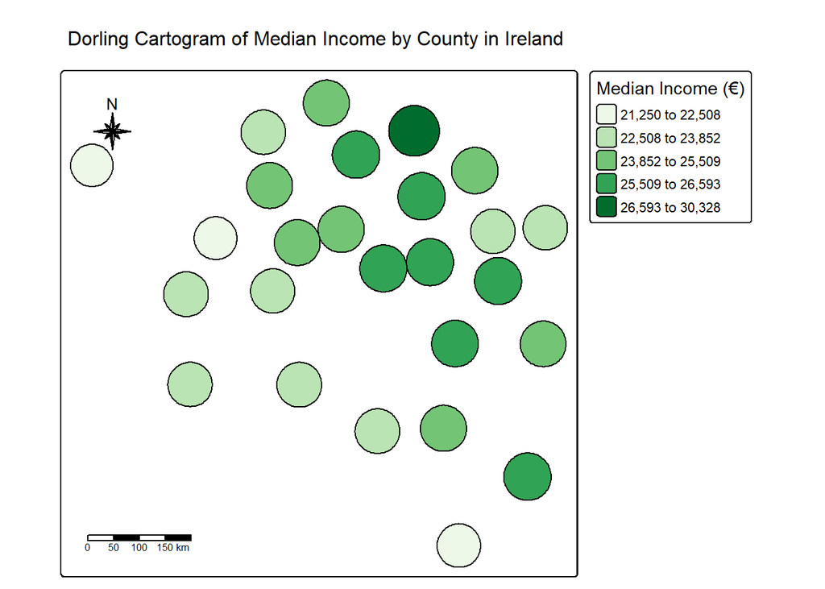

```r
# Reproject your spatial data first
counties_income_proj <- sf::st_transform(counties_income, 3112)

# Now create the Dorling cartogram
county_cartogram_dorling <- cartogram::cartogram_dorling(counties_income_proj, "mdn_income", k = 1)

# Set tmap to plot mode
tmap::tmap_mode("plot")

# Plot the Dorling cartogram
tmap::tm_shape(county_cartogram_dorling) +
  tm_polygons(
    fill = "mdn_income",
    fill.scale = tm_scale_intervals(values = "brewer.greens", style = "jenks"),
    fill.legend = tm_legend(title = "Median Income (€)"),
    col = "black"
  ) +
  tm_scalebar(position = c("left", "bottom")) +
  tm_compass(type = "8star", size = 2, position = c("left", "top")) +
  tm_title("Dorling Cartogram of Median Income by County in Ireland")
```